# Project Foundations for Data Science: FoodHub Data Analysis

**Marks: 60**

### Context

The number of restaurants in New York is increasing day by day. Lots of students and busy professionals rely on those restaurants due to their hectic lifestyles. Online food delivery service is a great option for them. It provides them with good food from their favorite restaurants. A food aggregator company FoodHub offers access to multiple restaurants through a single smartphone app.

The app allows the restaurants to receive a direct online order from a customer. The app assigns a delivery person from the company to pick up the order after it is confirmed by the restaurant. The delivery person then uses the map to reach the restaurant and waits for the food package. Once the food package is handed over to the delivery person, he/she confirms the pick-up in the app and travels to the customer's location to deliver the food. The delivery person confirms the drop-off in the app after delivering the food package to the customer. The customer can rate the order in the app. The food aggregator earns money by collecting a fixed margin of the delivery order from the restaurants.

### Objective

The food aggregator company has stored the data of the different orders made by the registered customers in their online portal. They want to analyze the data to get a fair idea about the demand of different restaurants which will help them in enhancing their customer experience. Suppose you are hired as a Data Scientist in this company and the Data Science team has shared some of the key questions that need to be answered. Perform the data analysis to find answers to these questions that will help the company to improve the business.

### Data Description

The data contains the different data related to a food order. The detailed data dictionary is given below.

### Data Dictionary

- order_id: Unique ID of the order
- customer_id: ID of the customer who ordered the food
- restaurant_name: Name of the restaurant
- cuisine_type: Cuisine ordered by the customer
- cost: Cost of the order
- day_of_the_week: Indicates whether the order is placed on a weekday or weekend (The weekday is from Monday to Friday and the weekend is Saturday and Sunday)
- rating: Rating given by the customer out of 5
- food_preparation_time: Time (in minutes) taken by the restaurant to prepare the food. This is calculated by taking the difference between the timestamps of the restaurant's order confirmation and the delivery person's pick-up confirmation.
- delivery_time: Time (in minutes) taken by the delivery person to deliver the food package. This is calculated by taking the difference between the timestamps of the delivery person's pick-up confirmation and drop-off information

### Let us start by importing the required libraries

```python
# import libraries for data manipulation
import numpy as np
import pandas as pd

# import libraries for data visualization
import matplotlib.pyplot as plt
import seaborn as sns
%matplotlib inline
```

```python
#allow import of foodhub dataset from google drive
from google.colab import drive
drive.mount('/content/drive')
```

### Understanding the structure of the data

```python
# read the data
df = pd.read_csv('/content/drive/MyDrive/foodhub_order.csv')
# returns the first 5 rows
df.head()
```

|  | order_id | customer_id | restaurant_name | cuisine_type | cost_of_the_order | day_of_the_week | rating | food_preparation_time | delivery_time |
| --- | --- | --- | --- | --- | --- | --- | --- | --- | --- |
| 0 | 1477147 | 337525 | Hangawi | Korean | 30.75 | Weekend | Not given | 25 | 20 |
| 1 | 1477685 | 358141 | Blue Ribbon Sushi Izakaya | Japanese | 12.08 | Weekend | Not given | 25 | 23 |
| 2 | 1477070 | 66393 | Cafe Habana | Mexican | 12.23 | Weekday | 5 | 23 | 28 |
| 3 | 1477334 | 106968 | Blue Ribbon Fried Chicken | American | 29.20 | Weekend | 3 | 25 | 15 |
| 4 | 1478249 | 76942 | Dirty Bird to Go | American | 11.59 | Weekday | 4 | 25 | 24 |

#### Observations:

- As observed from the head function, there are 9 unique columns detailing orders placed by customers.

### **Question 1:** How many rows and columns are present in the data? [0.5 mark]

```python
# Use shape function to determine number of rows and columns
df.shape
```

```
(1898, 9)
```

#### Observations:

- As observed by the shape function, there are 1898 rows and 9 columns.

### **Question 2:** What are the datatypes of the different columns in the dataset? (The info() function can be used) [0.5 mark]

```python
# Use info() to print a concise summary of the DataFrame
df.info()
```

```
<class 'pandas.core.frame.DataFrame'>
RangeIndex: 1898 entries, 0 to 1897
Data columns (total 9 columns):
 #   Column                 Non-Null Count  Dtype
---  ------                 --------------  -----
 0   order_id               1898 non-null   int64
 1   customer_id            1898 non-null   int64
 2   restaurant_name        1898 non-null   object
 3   cuisine_type           1898 non-null   object
 4   cost_of_the_order      1898 non-null   float64
 5   day_of_the_week        1898 non-null   object
 6   rating                 1898 non-null   object
 7   food_preparation_time  1898 non-null   int64
 8   delivery_time          1898 non-null   int64
dtypes: float64(1), int64(4), object(4)
memory usage: 133.6+ KB
```

#### Observations:

- As observed from the info function, columns 'restaurant_name', 'cuisine_type', 'day_of_the_week', and 'rating' are dtype 'object'. Columns 'order_id', 'customer_id', 'food_preparation_time', and 'delivery_time' are dtype 'int64' dtype. Column 'cost_of_the_order' is dtype 'float64' dtype.
- All columns have equal row numbers, indicating no presence of null values.

### **Question 3:** Are there any missing values in the data? If yes, treat them using an appropriate method. [1 mark]

```python
# Use the isnull().sum() function to check for missing values
df.isnull().sum()
```

|  | 0 |
| --- | --- |
| order_id | 0 |
| customer_id | 0 |
| restaurant_name | 0 |
| cuisine_type | 0 |
| cost_of_the_order | 0 |
| day_of_the_week | 0 |
| rating | 0 |
| food_preparation_time | 0 |
| delivery_time | 0 |

**dtype:** int64

#### Observations:

- As observed by the isnull().sum() functions, there are no missing values within the columns.

### **Question 4:** Check the statistical summary of the data. What is the minimum, average, and maximum time it takes for food to be prepared once an order is placed? [2 marks]

```python
# Use the describe() function to check the statisical summary of numerical columns
df[['cost_of_the_order', 'food_preparation_time', 'delivery_time']].describe().T
```

|  | count | mean | std | min | 25% | 50% | 75% | max |
| --- | --- | --- | --- | --- | --- | --- | --- | --- |
| cost_of_the_order | 1898.0 | 16.498851 | 7.483812 | 4.47 | 12.08 | 14.14 | 22.2975 | 35.41 |
| food_preparation_time | 1898.0 | 27.371970 | 4.632481 | 20.00 | 23.00 | 27.00 | 31.0000 | 35.00 |
| delivery_time | 1898.0 | 24.161749 | 4.972637 | 15.00 | 20.00 | 25.00 | 28.0000 | 33.00 |

### **Question 5:** How many orders are not rated? [1 mark]

```python
# Use the value.counts() function on the 'rating' variable
df['rating'].value_counts()
```

| rating | count |
| --- | --- |
| Not given | 736 |
| 5 | 588 |
| 4 | 386 |
| 3 | 188 |

**dtype:** int64

#### Observations:

- As observed from using the value_counts function, there are 736 denoted 'Not given'orders representing orders not rated.
- This would seem to suggest that customers are failing to be properly engaged into giving a rating feedback.
- Service would be improved by creating a system that encourages customers to participate in rating feedback.

### Exploratory Data Analysis (EDA)

### **Question 6:** Explore all the variables and provide observations on their distributions. (Generally, histograms, boxplots, countplots, etc. are used for univariate exploration.) [9 marks]

**Order ID: Unique ID of the order**

```python
#use nunique() function to check number of unique values
order_id_unique = df['order_id'].nunique()
order_id_unique
```

```
1898
```

- As observed by the nunique function, there are 1898 unique values of order ID.

**Customer ID: ID of the customer who ordered the food**

```python
#use nunique() function to check number of unique values
customer_id_unique = df['customer_id'].nunique()
customer_id_unique
```

```
1200
```

- As observed from the nunique function, there are 1200 unique values of customer ID.
- This would indicate that there are a number of repeat customers who make repeat orders.
- Is is important for Foodhub to focus on developing tactics to retain these repeat customers and to attract potential repeat customers.

**Restaurant name: Name of the restaurant**

```python
# Use describe() to get unique values of non-numeric variables
df['restaurant_name'].describe().T #Transpose df with .T
```

|  | restaurant_name |
| --- | --- |
| count | 1898 |
| unique | 178 |
| top | Shake Shack |
| freq | 219 |

**dtype:** object

- As observed from the describe function, there are 178 different restaurants.
- The restaurant 'Shack Shack' is the most popular with 219 separate orders.

**Cuisine type: Cuisine ordered by the customer**

```python
# Use describe() to get unique values of non-numeric variables
df['cuisine_type'].describe().T
```

|  | cuisine_type |
| --- | --- |
| count | 1898 |
| unique | 14 |
| top | American |
| freq | 584 |

**dtype:** object

- As observed from the describe function, there are 14 cuisine types.
- 'American' cuisine is the most popular with 584 orders.

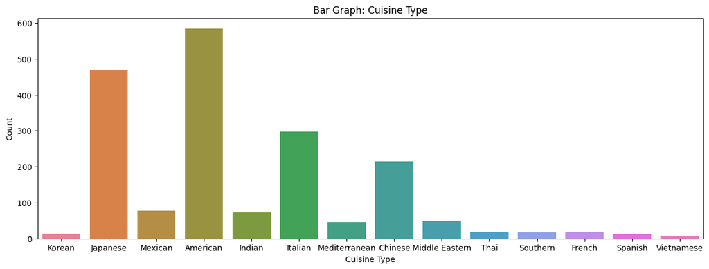

```python
# create countplot to visualize the count distribution of different cuisine types
plt.figure(figsize=(15,5)) #expand size of the countplot
plt.title('Bar Graph: Cuisine Type') #title
plt.xlabel('Cuisine Type') #x-axis label
plt.ylabel('Count') #y-axis label
sns.countplot(data=df, x='cuisine_type', hue='cuisine_type'); #implemented hue for contrasting coloration
```

- We can observe from the above plot that there are 4 major categories of popular cuisine types(American, Japanese, Italian, Chinese), with 'American' by far being the overall most popular choice.
- The higher demand could be due to these cuisines being widely recognized and widely available. The restaurants of these popular cuisines having more orders, shows this strong customer preference.
- Following these customer tendencies in order to develop a larger order volume from a greater user base, Foodhub should be consider developing partnerships with restaurants offering the most popular cuisines.
- The plot shows some other cuisines(Mexican, Indian, Mediterranean, Middle Eastern) have the potential to grow with targeted promotions.

**Cost: Cost of the order**

```
count    1898.000000
mean       16.498851
std         7.483812
min         4.470000
25%        12.080000
50%        14.140000
75%        22.297500
max        35.410000
Name: cost_of_the_order, dtype: float64
```

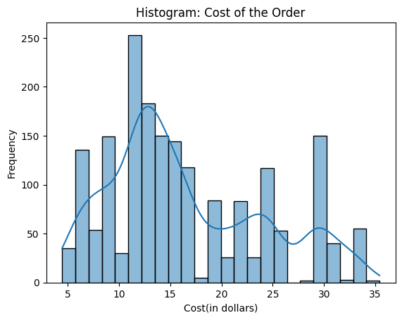

```python
# Use describe() to get summary statistics
print(df['cost_of_the_order'].describe().T)
print('\n')
#diplay histogram of continuous numerical variable'cost_of_the_order'
plt.title('Histogram: Cost of the Order') #title
plt.xlabel('Cost(in dollars)') #x-axis label
plt.ylabel('Frequency') #y-axis label
sns.histplot(data=df, x='cost_of_the_order',bins=24, kde=True); #applied bins to set intervals and kde to apply kernal density estimate
```

- We can observe from the above histogram plot, that the tallest cluster of bars is around a cost of 12 to 14 dollars, showing the cost value of most orders.
- Its distribution appears multimodal and not symmetrical with a positive skew represented by right-sided tail, an effect due to a sizeable number of higher-end cost purchases.

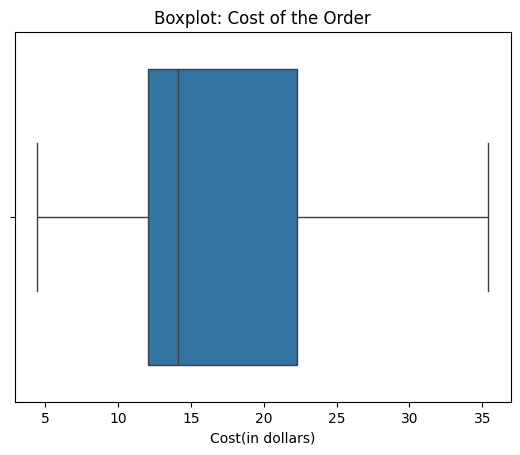

```python
#display boxplot for continuous numerical variable "cost_of_the_order"
plt.title('Boxplot: Cost of the Order') #title
plt.xlabel('Cost(in dollars)') #x-axis label
sns.boxplot(data=df, x='cost_of_the_order');
```

- The above boxplot better shows the postive skew, having the median closer to the left side of the box and a shorter left-sided whisker. The range between Q1 and the median is small, indicating many lower priced orders. The middle 50% of orders fall with 12 to 22 dollars. Only 25% have a cost more than 22.3 dollars.

**Day of the week: Indicates whether the order is placed on a weekday(Monday-Friday) or weekend(Saturday-Sunday)**

```python
#use nunique() function to check number of unique values
day_of_the_week_unique = df['day_of_the_week'].nunique()
day_of_the_week_unique
```

```
2
```

- As observed from the nunique function, here are two unique values in the day of the week category.

```
count        1898
unique          2
top       Weekend
freq         1351
Name: day_of_the_week, dtype: object
```

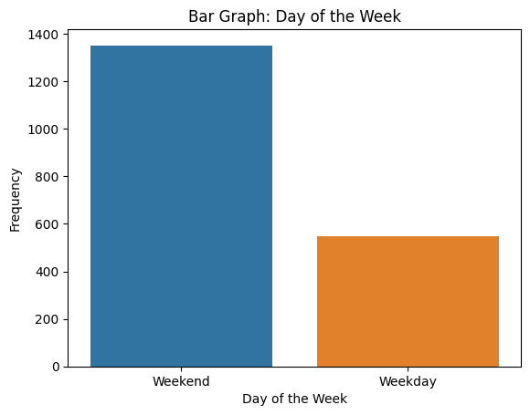

```python
# Use describe() to get unique values of non-numeric variables
print(df['day_of_the_week'].describe().T)
print('\n')
#display countplot of categorical variable 'day_of_the_week'
plt.title('Bar Graph: Day of the Week') #title
plt.xlabel('Day of the Week') #x-axis label
plt.ylabel('Frequency') #y-axis label
sns.countplot(data=df, x='day_of_the_week', hue='day_of_the_week'); #utilized hue for contrasting colors
```

- The above countplot shows that the weekend(1351) is much more popular than weekdays(547), having more than 70% of orders placed on weekends in the Foodhub app.
- This could be due to circumstances related to customers differing attitudes between the two. The weekend is usually associated with social gatherings and more casual dining habits. For budget-minded customers, delivery could be considered a luxury and weekends are when they are more willing to spend their disposable income.
- The company should determine strategies for taking advantage of the weekend higher surge of orders, as well as promotional offers to entice more use during the weekdays.

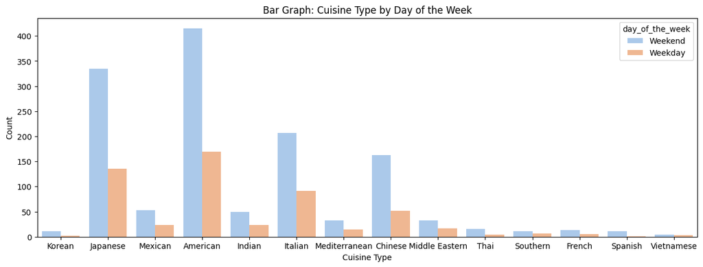

```python
plt.figure(figsize=(15,5)) #expand size of the countplot
plt.title('Bar Graph: Cuisine Type by Day of the Week') #title
plt.xlabel('Cuisine Type') #x-axis label
plt.ylabel('Count') #y-axis label
sns.countplot(data=df, x='cuisine_type', hue='day_of_the_week', palette='pastel'); #applied hue for contrasting coloration
```

- The above countplot affirms American restaurants are the dominant choice on weekdays and weekends. American food is a likely choice for social events where items such as burgers, wings, sandwiches, and hotdogs are a common staple. American is less than the weekend but stil the most popular weekday choice, possibly due to its diverse options that appeal for different settings.

**rating: Rating given by the customer out of 5**

```python
# Use describe() to get unique values of non-numeric variables
df['rating'].describe().T
```

|  | rating |
| --- | --- |
| count | 1898 |
| unique | 4 |
| top | Not given |
| freq | 736 |

**dtype:** object

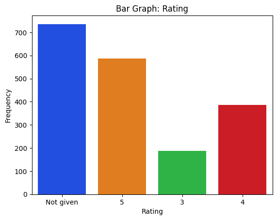

```python
#display countplot of categorical variable 'rating'
plt.title('Bar Graph: Rating') #title
plt.xlabel('Rating') #x-axis label
plt.ylabel('Frequency') #y-axis label
sns.countplot(data=df, x='rating', hue='rating', palette='bright'); #utilized hue and palette for contrasting coloration
```

**Food preparation time: Time(in minutes) taken by restaurant to prepare the food**

```
count    1898.000000
mean       27.371970
std         4.632481
min        20.000000
25%        23.000000
50%        27.000000
75%        31.000000
max        35.000000
Name: food_preparation_time, dtype: float64
```

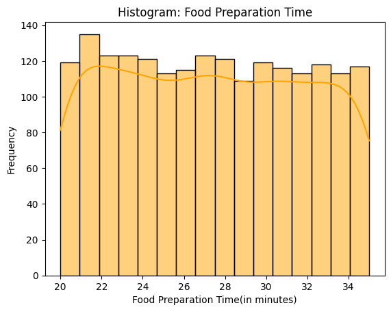

```python
print(df['food_preparation_time'].describe().T) #display statistic summary for cost
print('\n')
# diplay histogram of continuous numerical variable'food_preparation_time'
plt.title('Histogram: Food Preparation Time') #title
plt.xlabel('Food Preparation Time(in minutes)') #x-axis label
plt.ylabel('Frequency') #y-axis label
sns.histplot(data=df, x='food_preparation_time', bins=16,  kde=True, color='orange'); #intervals set to 16 and kernal density estimate applied
```

- The above histogram plot shows that food preparation appears evenly distributed across time intervals.

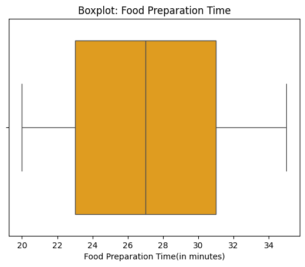

```python
# display boxplot for continuous numerical variable 'food_preparation_time'
plt.title('Boxplot: Food Preparation Time') #title
plt.xlabel('Food Preparation Time(in minutes)') #x-axis label
sns.boxplot(data=df, x='food_preparation_time', color='orange');
```

- The above boxplot of food preparation time shows an even distribution. Average food prep time is around 27 minutes, with a range from 20 to 35 minutes.

**Delivery time: Time(in minutes) taken by the delivery person to deliver the food package**

```
count    1898.000000
mean       24.161749
std         4.972637
min        15.000000
25%        20.000000
50%        25.000000
75%        28.000000
max        33.000000
Name: delivery_time, dtype: float64
```

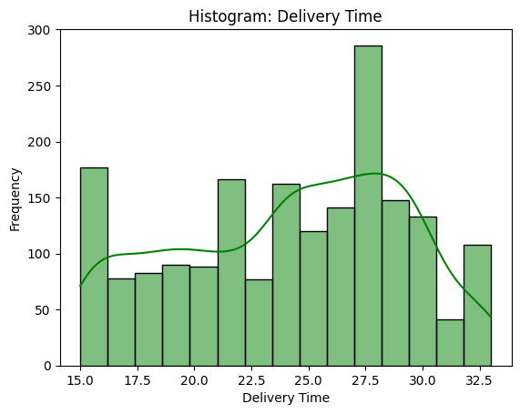

```python
print(df['delivery_time'].describe().T) #display statistic summary for cost
print('\n')
# diplay histogram of continuous numerical variable 'delivery_time'
plt.title('Histogram: Delivery Time') #title
plt.xlabel('Delivery Time') #x-axis label
plt.ylabel('Frequency') #y-axis label
sns.histplot(data=df, x='delivery_time', bins=15, color='green', kde=True); #intervals set to 15 and kernal density estimate applied
```

- The above histogram plot shows a large peak around 27.5 minutes.
- It has a negative skew indicated by a longer left-sided tail.\

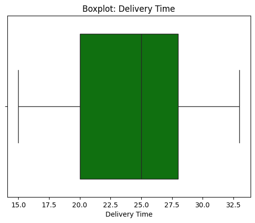

```python
# display boxplot for continuous numerical variable 'delivery_time'
plt.title('Boxplot: Delivery Time') #title
plt.xlabel('Delivery Time') #x-axis label
sns.boxplot(data=df, x='delivery_time', color='green');
```

- The above boxplot of delivery time shows a median delivery time around 25 minutes. There is an noticeable negative skewed distribution, indicated by the medians closer proximity to the right side of the box and its right-sided whisker being shorter.

### **Question 7**: Which are the top 5 restaurants in terms of the number of orders received? [1 mark]

```python
# Use value_counts() function on 'restaurant_name'
top_five_rest = df['restaurant_name'].value_counts().head(5).copy()
top_five_rest
```

| restaurant_name | count |
| --- | --- |
| Shake Shack | 219 |
| The Meatball Shop | 132 |
| Blue Ribbon Sushi | 119 |
| Blue Ribbon Fried Chicken | 96 |
| Parm | 68 |

**dtype:** int64

#### Observations:

- As observed from using the value_count function on restaurant name,the five top choices were Shack Shack(219), The Meatball Shop(132), Blue Ribbon Sushi(119), Blue Ribbon Fried Chicken(96), Parm(68). All fall within the most popular cuisine types.
- Following the evidence of popular consumer behavior, these popular restaurants would be top targets for the expanded partnerships. Collaboration on promotional deals can drive an increase in traffic to the app, boost order volume, and increase Foodhubs profitability.

### **Question 8**: Which is the most popular cuisine on weekends? [1 mark]

```python
#use the functions groupby(), count(), and sort_values to determine most popular weekend cuisine
popular_weekend_cuisine = df.groupby(['day_of_the_week', 'cuisine_type'])['cuisine_type'].count().sort_values(ascending=False).head(1).copy()
popular_weekend_cuisine
```

| day_of_the_week | cuisine_type | cuisine_type |
| --- | --- | --- |
| Weekend | American | 415 |

**dtype:** int64

#### Observations:

- As shown by the groupby, count, and sort_values function, The most popular cuisine is American at an order count of 415. This is corraborated with the bar graph displayed earlier.
- As earlier expressed, the is due to the wide availablity of restaurants serving American-style food. Popular items like burgers are universally recognized and appeal to a broad range of people.
- Foodhub should capitalize on the higher weekend volume with promotional offers for these popular American-style restaurants.

### **Question 9**: What percentage of the orders cost more than 20 dollars? [2 marks]

```python
# Create new variable greater_than_20 from df[df['cost_of_the_order'] > 20]
greater_than_20 = df[df['cost_of_the_order'] > 20]
greater_than_20.shape[0] #determine number of rows in greater_than_20 variable
greater_than_20_percent = (greater_than_20.shape[0] / df.shape[0]) * 100 #create variable to determine % by dividing greater_than_20.shape[0] from df.shape[0]
greater_than_20_percent
```

```
29.24130663856691
```

#### Observations:

- The number of orders that cost more than 20 dollars is around 29%. The multimodal, positive skewed appearance seen in the histogram and boxplot distribution can be attributed to this.
- More than 70% of orders cost 20 dollars or less, pointing towards most customers preference to opt for affordable meals. However, 29% is a sizeable segment of orders, suggesting a opportunity to market higher priced purchases to a receptive customers. Boosting higher priced orders would help increase the companies profit margins.

### **Question 10**: What is the mean order delivery time? [1 mark]

```python
# use mean function on df['delivery_time'] to determine the average delivery time
mean_delivery_time = df['delivery_time'].mean()
mean_delivery_time
```

```
np.float64(24.161749209694417)
```

#### Observations:

- The mean order delivery time is 24.16 minutes. This aligns with the left-skewed distribution in the histogram.
- Looking for ways to optimize the time it takes to deliver the customers orders could potentially lead to higher customer satisfaction and repeat business.

### **Question 11:** The company has decided to give 20% discount vouchers to the top 3 most frequent customers. Find the IDs of these customers and the number of orders they placed. [1 mark]

```python
# create variable using value_counts() function on df['customer_id]
most_frequent_customers = df['customer_id'].value_counts().head(3).copy() #use head(3) to select top 3 counts
most_frequent_customers
```

| customer_id | count |
| --- | --- |
| 52832 | 13 |
| 47440 | 10 |
| 83287 | 9 |

**dtype:** int64

#### Observations:

- The 3 most frequent customers have the customer_id: 52832, 47440, 83287.
- This would be an important strategy to boost user engagement and develop the loyalty of users in using the Foodhub app. offering the top repeat customers with exclusive discounts and rewards.

### **Question 12**: Perform a multivariate analysis to explore relationships between the important variables in the dataset. (It is a good idea to explore relations between numerical variables as well as relations between numerical and categorical variables) [10 marks]

**Food Preparation Time by Cuisine Type**

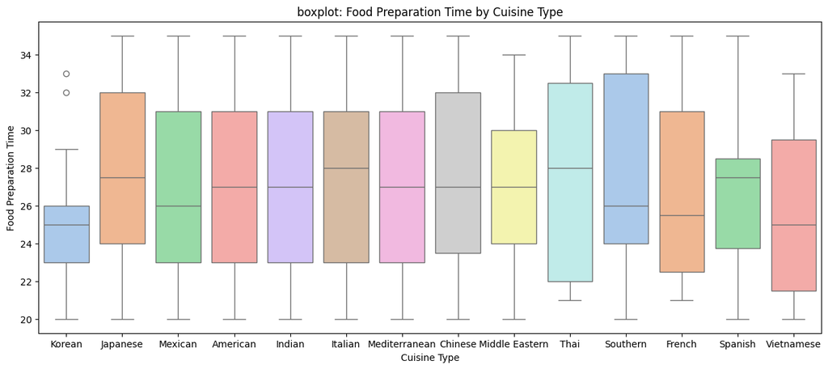

```python
# display boxplot to visualize the distribution of 'food_preparation_time' for different 'cuisine_type'
plt.figure(figsize=(15,6)) #reconfigure size
plt.title('boxplot: Food Preparation Time by Cuisine Type') #title
plt.xlabel('Cuisine Type') #x-axis label
plt.ylabel('Food Preparation Time') #y-axis label
sns.boxplot(data=df, x='cuisine_type', y='food_preparation_time', hue='cuisine_type', palette='pastel');
```

- The above boxplot shows the median food preparation time being fairly consistent across cuisine types. This suggests that restaurants maintain a predictable cooking time regardless of cuisine type.
- Among the four most popular cuisines, Japanese and Italian have slightly higher prep time compared to American and Chinese. This difference could be due to the complexity in food preparing techniques.
- The IQR varies across cuisines, suggesting certain dishes might require more preparation which increases the preparation time.
- Consumers might lean towards faster prepared cuisines, but it can be dependant on others factors such as cost and quality of the food.

**Rating vs. Food Preparation Time**

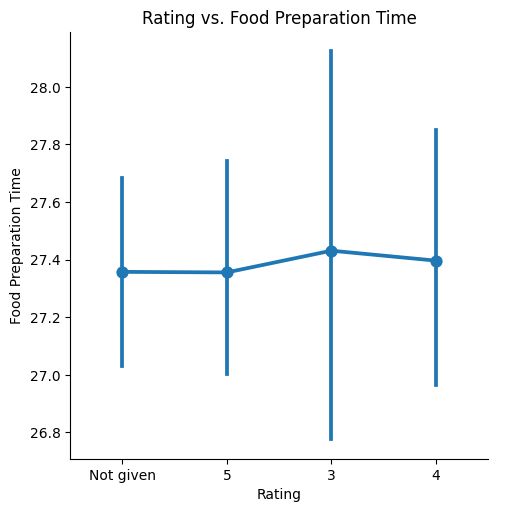

```python
# Display catplot in pointplot form to visualize overall relation between rating and food preparation time
sns.catplot(data=df, x='rating', y='food_preparation_time', kind='point'); #pointplot
plt.xlabel('Rating') #x-axis label
plt.ylabel('Food Preparation Time') #y-axis label
plt.title('Rating vs. Food Preparation Time') #title
plt.show()
```

- The above plot shows that higher ratings tend to align with moderate food preparation times, suggesting that customers appreciate a balance between speed and quality.
- Lower ratings are not necessarily due to longer preparation times, suggesting that customers may be fine with longer waits if the food quality meets their expectations.
- Lower ratings show a wider spread in food preparation time. This can indicate there is a inconsistency in service which could be a problem. If food preparation time is taking longer than expected by the customers, could lead to a downgrade in rating satisfaction.
- An audit system of restaurants should be put in place. This implemented in conjunction with customer feedback reviews can help to resolve inconsistencies that customers may find unsatisfactory.

[figure not shown]

```python
#Display catplot in pointplot form to visualize relation between rating and food preparation time for different cuisine types
sns.catplot(data=df, x='rating', y='food_preparation_time', kind='point', hue='cuisine_type', col='cuisine_type'); #pointplot for different cuisines
#click to expand size
```

- The plot shows that most cuisines follow the general trend that higher ratings align with moderate food preparation time.
- Most cuisines show that lower ratings isn't necessarily due to longer food preparation times. There are exceptions such as Mexican where lower ratings concides with longer times, and Southern where lower ratings concide with too short of time. So customer expectations need to possibly have cuisine type taken into account.
- Every cuisine type has greater spread in the lower ratings, reinforcing the need for an audit system and strong customer review feedback that encompasses the problems in need of remediation.
- Foodhub can provide feedback to the restaurants and incentivize resolving these issues with promotional awards for improvement.

**Delivery Time vs. Day of the Week**

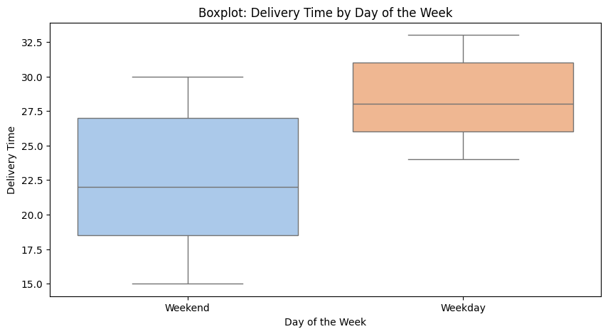

```python
# use boxplot to visualize differences in delivery times between weekend and weekdays
plt.figure(figsize=(10,5)) #reconfigure size
plt.title('Boxplot: Delivery Time by Day of the Week') #title
plt.xlabel('Day of the Week') #x-axis label
plt.ylabel('Delivery Time') #y-axis label
sns.boxplot(data=df, x='day_of_the_week', y='delivery_time', hue='day_of_the_week', palette='pastel');
```

- The weekend boxplot has a lower median than the weekday median. This suggests that deliveries tend to take longer on the weekdays. This could possibly be due to more traffic congestion on weekdays which are working days.
- The longer weekday delivery times could indicate operational inefficiencies, which could possibly be remedied by optimizing drivers routes or increasing the pool of available delivery drivers.
- The interquartile range is wider for the weekend boxplot, suggesting greater variability in delivery times. This could be related to there being many more orders taken on the weekend and a greater range of destinations. E.g. people homes or social gathering areas vs. business centers.

**Delivery Time by Cuisine Type**

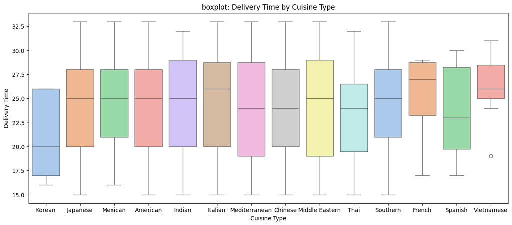

```python
# display boxplot to visualize the distribution of 'food_preparation_time' for different 'cuisine_type'
plt.figure(figsize=(15,6)) #reconfigure size
plt.title('boxplot: Delivery Time by Cuisine Type') #title
plt.xlabel('Cuisine Type') #x-axis label
plt.ylabel('Delivery Time') #y-axis label
sns.boxplot(data=df, x='cuisine_type', y='delivery_time', hue='cuisine_type', palette='pastel');
```

- The boxplot above shows that the median delivery time appears fairly consistent across most cuisine types. The typical delivery time is around 25-27min.
- Yet, the IQR is fairly wide for most cuisines, which could suggest inconsistent delivery times that point towards delivery service inefficiencies.
- It however could be related to factors such as relative differences in distance between restaurant and recipient, time of day related to traffic congestation. It would be important to look at individual restaurants delivery time data and average delivery times during hours of the day.

**Rating vs. Delivery Time**

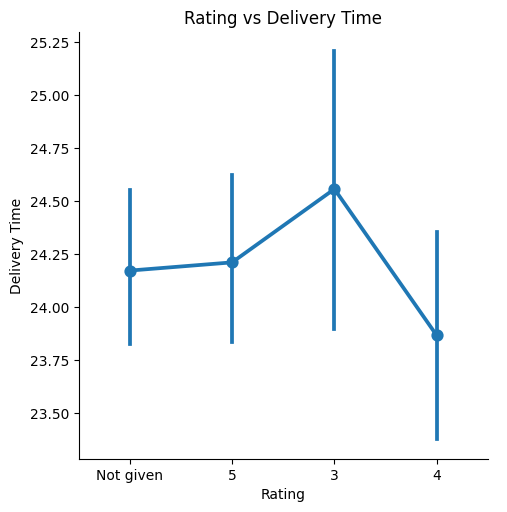

```python
# Display catplot in pointplot form to visualize overall relation between rating and delivery time
sns.catplot(data=df, x='rating', y='delivery_time', kind='point'); #pointplot
plt.xlabel('Rating') #x-axis label
plt.ylabel('Delivery Time') #y-axis label
plt.title('Rating vs Delivery Time') #title
plt.show()
```

- THe plot above shows higher ratings being correlated with lower delivery times, indicating that customers favor quicker deliveries to a certain extent. 4 Ratings show quicker deliveries, even though its a lower rating than 5.
- Lower ratings show a wider spread in delivery times. This can indicate there is a inconsistency in service which could be a problem. If deliveries are taking longer than expected by the customers, could lead to a downgrade in rating satisfaction.
- It would be important to implement advanced routing optimization software to find the quickest routes to cut down delivery times.
- It would be best to compile the data and create a heatmap tracking where deliveries take place during the day. Leverage this information to determine where to apportion drivers to areas as needed and be sure to have a robust number of delivery drivers that can meet those needs.
- If not already utilized, a real-time visibility tool for the customers could keep customers informed about their order status, which can boost transparency and trust.

[figure not shown]

```python
#Display catplot in pointplot form to visualize relation between rating and delivery time for different cuisine types
sns.catplot(data=df, x='rating', y='delivery_time', kind='point', hue='cuisine_type', col='cuisine_type'); #pointplot for different cuisines
#click to expand size
```

- The above plot shows most cuisines following the general trend of higher ratings being correlated with lower delivery times and lower ratings correlated with higher delivery times. A few exceptions are Italian and Middle eastern, which could be due to customers expectations that these cuisines aren't as ubiquitous and travel time may take longer as they come from certain areas.
- Having a robust review system with specific questions related to delivery time expectations could help improve understanding customer sentiment.

**Cost of the Order by Cuisine Type**

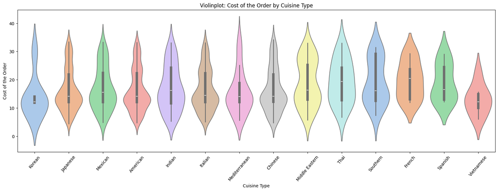

```python
#display violinplot to visualize the distribution of 'cost_of_the_order' for different 'cuisine_type'
plt.figure(figsize=(20,6)) #reconfigure size
plt.title('Violinplot: Cost of the Order by Cuisine Type') #title
plt.xlabel('Cuisine Type') #x-axis label
plt.ylabel('Cost of the Order') #y-axis label
plt.xticks(rotation=50); #rotate x-axis labels
sns.violinplot(data=df, x='cuisine_type', y='cost_of_the_order',palette='pastel', hue='cuisine_type');
```

- The above violin plot shows some of the cuisines having a wider IQR than others. This could indicate a greater diversity in pricing within the category. This may dissuade customers from purchasing from certain cuisine types.
- For certain cuisines(American, Japanese Italian, Chinese, Mediterranean orders), their median and first quartile(Q1) have a narrow range within the lower cost orders. This indicates greater affordability which is appealing to customers. This is backed up by the density centered primarily around the lower range of order costs. Customers tend to appraise affordable options.
- Some of the cuisines such as Middle eastern or Southern, have a higher range between the median and the third quartile of their IQR, meaning many higher priced orders which can dissuade possible customers from ordering. There is potential growth in working with these restaurants to create deals on certain items such as offering a lunch special, could help drive customer order volume.

**Rating vs. Cost of the Order**

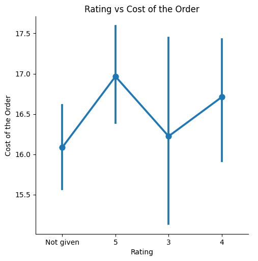

```python
# Display catplot in pointplot form to visualize relation between rating and cost of the order
sns.catplot(data=df, x='rating', y='cost_of_the_order', kind='point'); #pointplot
plt.xlabel('Rating') #x-axis label
plt.ylabel('Cost of the Order') #y-axis label
plt.title('Rating vs Cost of the Order')
plt.show()
```

- The above plot shows higher ratings being correlated with higher cost orders. This could suggest that even though most customers gravitate towards more affordable options, customers are more satisfied with their higher priced meals.
- Lower rated orders tend to have lower prices, suggesting that affordability alone doesn't guarantee satisfaction. There is however greater variability of prices in the lower ratings, suggesting there are other factors influencing the rating in conjunction with price.

[figure not shown]

```python
#Display catplot in pointplot form to visualize relation between rating and cost of the order for different cuisine types
sns.catplot(data=df, x='rating', y='cost_of_the_order', kind='point', hue='cuisine_type', col='cuisine_type'); #pointplot for different cuisines
#click to expand size
```

- The above display shows cost of the order can be dependant on which cuisine type is chosen. American, Italian, French, and Vietnamese follow the pattern of higher rating for higher priced orders, but others such as Indian or Middle eastern do not show this.
- This could be due to customer expectations dependant on the specific cuisine and these insights could be enhanced wih improved customer feedback on a robust questionaire rating survey.

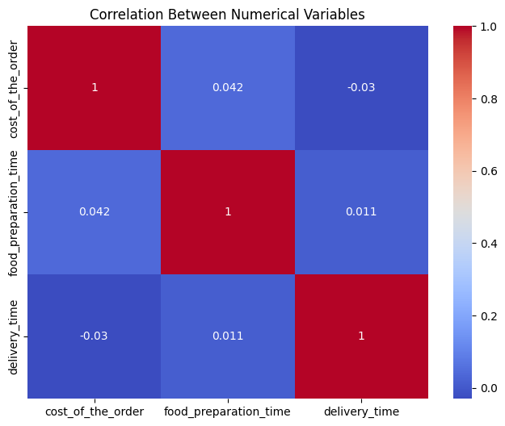

```python
#display heatmap to visualize the correlation strength amongst 'cost_of_the_order, 'food_preparation_time', and 'delivery_time'
plt.figure(figsize=(8,6)) #reconfigure size
sns.heatmap(df[['cost_of_the_order', 'food_preparation_time', 'delivery_time']].corr(), annot=True, cmap='coolwarm')
plt.title('Correlation Between Numerical Variables') #title
plt.show()
```

- The heatmap shows weak correlation between delivery time, food preparation time, and the cost of the order, meaning there isn't a strong linear relationship between them.
- The weak correlation of cost of the order with food preparation time and delivery time, would seem to suggest that higher cost orders don't necessarily take longer to prepare or deliver. The higher cost could be due to the quality level, such as utilizing more expensive ingredients, rather than complexity of the food preparation methods.

### **Question 13:** The company wants to provide a promotional offer in the advertisement of the restaurants. The condition to get the offer is that the restaurants must have a rating count of more than 50 and the average rating should be greater than 4. Find the restaurants fulfilling the criteria to get the promotional offer. [3 marks]

```python
# Filter out 'Not given' unique values
rated_df = df[df['rating'] != 'Not given'].copy() #make a copy

#convert 'rating' from object to int type
rated_df['rating'] = rated_df['rating'].astype(int)
```

```python
# Grouped restaurants and calculated their rating count and mean
grouped_rest = rated_df.groupby('restaurant_name').agg({'rating': ['count', 'mean']}).reset_index()

# Renamed the columns
grouped_rest.columns = ['restaurant_name', 'rating_count', 'rating_mean']

# Filter restaurants > 50 ratings and average rating > 4
restaurant_names_promo_offer = grouped_rest[(grouped_rest['rating_count'] > 50) & (grouped_rest['rating_mean'] > 4)]

# Display the restaurants
restaurant_names_promo_offer
```

|  | restaurant_name | rating_count | rating_mean |
| --- | --- | --- | --- |
| 16 | Blue Ribbon Fried Chicken | 64 | 4.328125 |
| 17 | Blue Ribbon Sushi | 73 | 4.219178 |
| 117 | Shake Shack | 133 | 4.278195 |
| 132 | The Meatball Shop | 84 | 4.511905 |

#### Observations:

- The restaurants eligible for the promotional offer are Blue Ribbon Fried Chicken, Blue Ribbon Sushi, Shack Shack, and The Meatball Shop. Promotional offers could be a great way to increase customer use of the service. Partnerships could be made with these restaurants to increase order volume for both Foodhub and the restaurants.
- Other restaurants can be incentivized to improve their ratings by offering promotions and visibility for their restaurants that can increase order volume.
- Higher popularity usually means higher order volume, necessitating a substantial presence of delivery drivers within the general area.

### **Question 14:** The company charges the restaurant 25% on the orders having cost greater than 20 dollars and 15% on the orders having cost greater than 5 dollars. Find the net revenue generated by the company across all orders. [3 marks]

```python
# Calculate profit margin per order using a lambda to apply if-else conditional statement to each order
df['fixed_margin'] = df['cost_of_the_order'].apply(lambda x: x * 0.25 if x > 20 else (x * 0.15 if x > 5 else 0))

# Compute total net revenue by taking sum of df['fixed_margin']
net_revenue = df['fixed_margin'].sum()

#display net revenue total
print(f"Company net revenue: ${net_revenue:.2f}")
```

```
Company net revenue: $6166.30
```

#### Observations:

- The net revenue of Foodhub was $6166.30.
- There is room to improve the total net revenue by increasing customer order volume and having more higher priced orders. This can involve targeted promotionals to get customers interested and exclusive deals on certain items such as on larger ticket items or add-ons items when buying large combo orders.There should be a primary focus on improving ratings by carefully reviewing customer feedback and acting on areas of concern.

### **Question 15:** The company wants to analyze the total time required to deliver the food. What percentage of orders take more than 60 minutes to get delivered from the time the order is placed? (The food has to be prepared and then delivered.) [2 marks]

```python
# Compute total time
df['total_time'] = df['food_preparation_time'] + df['delivery_time']

# Compute percentage of orders >60min
total_time_over_sixty = (df['total_time'] > 60).mean() * 100

#display result
print(f"Percentage of orders that take more than 60 minutes: {total_time_over_sixty:.2f}%")
```

```
Percentage of orders that take more than 60 minutes: 10.54%
```

[figure not shown]

```python
#Display catplot in pointplot form to visualize relation between rating and total time for different cuisine types
sns.catplot(data=df, x='rating', y='total_time', kind='point', hue='cuisine_type', col='cuisine_type'); #pointplot for different cuisines
#click to expand size
```

### **Question 16:** The company wants to analyze the delivery time of the orders on weekdays and weekends. How does the mean delivery time vary during weekdays and weekends? [2 marks]

```python
# Calculate average delivery time on Weekdays and Weekends
avg_delivery_time = df.groupby('day_of_the_week')['delivery_time'].mean()
avg_delivery_time
```

| day_of_the_week | delivery_time |
| --- | --- |
| Weekday | 28.340037 |
| Weekend | 22.470022 |

**dtype:** float64

#### Observations:

- The average delivery time for the weekday is 28.34 minutes and 22.47 for the weekend. As shown earlier in the boxplot, weekdays have longer delivery times. This could be due to increased traffic congestion during working hours, which would slow down delivery time. The company could implement route optimization software to find better alternative routes to minimize delivery times. Could also implement smaller vehicles such as scooters or bikes that can better navigate through impeding traffic.
- Weekends have shorter delivery times, but as shown in the boxplot have greater variability. Higher order volume can lead to these fluctuations, when demand and location is taken into account. Ensuring there is a substantial pool of delivery drivers at the necessary locations during peak hours is required.

### Conclusion and Recommendations

### **Question 17:** What are your conclusions from the analysis? What recommendations would you like to share to help improve the business? (You can use cuisine type and feedback ratings to drive your business recommendations.) [6 marks]

### Conclusions:

The analysis has found several trends in customer behavior, order characteristics and operational efficiency:

- American cuisine is the most popular cuisine type to order among the customers. It has the most popular restaurant. Along with Japanese, Italian and Chinese, these form the major popular choices. The top five choices all fall within these categories. The high order volume shows strong customer preference. Restaurant popularity drives order volume, so Foodhub should leverage these popular cuisines by strengthening partnerships with these particular restaurants.
- The weekend dominates order volume with over 70% of orders made on weekends, particularly for American cuisine. Strategic promotions could capitalize on this trend.
- Customer ratings need improvement, with 39% having no rating. This indicates low customer engagement with feedback. Most given ratings are 5 stars, but lower ratings correlate with inconsistencies in prep or delivery times.
- High-Cost Orders comprise 29%. with Nearly 30% of orders cost more than $20, showing opportunities for premium purchases.
- Delivery efficiency varies with delivery times generally quicker on weekends, with weekdays slowed down by traffic congestion.
- Ratings correlate with moderate prep and faster delivery, with customers prefering a balance of food quality and speed. Inconsistencies lead to lower ratings.

### Recommendations:

- Via collaborative partnerships with the most popular restaurants in the most popular cuisine types, a promotional strategy can be devised to offer appealing exclusive deals that will drive customer engagement. The restaurants can be offered premium visibility on the app or negotiated commision rates to drive sales.
- Foodgrub should offer weekend promotions to capitalize on peak ordering periods. Special weekend exclusive promotions can drive engagement. Alternatively, surge pricing can boost Foodgrubs revenue. Strategic weekday discounts can be offered to boost engagement during slower periods.
- A new robust rating review system needs to be implemented to increase customer engagement. The users should be incentivized in leaving ratings by offering rewards such as exclusive discounts or loyalty points that can be accumulated and used for purchases. This feedback can be used to refine service by addressing inconsistencies in food preparation and delivery time.
- A possible option to increase net revenue, is a strategy to try and work around most customers overall preference for an affordable cost order, is to offer promotional deals for higher priced orders. Promote high cost orders with bundle deals or waive delivery fees to encourage premium purchases.
- An audit system of restaurants should be put in place. This implemented in conjunction with customer feedback reviews can help to resolve inconsistencies that customers may find unsatisfactory.
- To address longer weekday delivery times on weekdays and in general, routing strategies need to be looked at and improved upon when needed. Implementing an advanced route optimization software program to find quickest routes could minimize delivery times. It would be important to compile data and create a heatmap tracking when and where deliveries typically take place and apportion the appropriate amount of delivery drivers to meet requirements to keep delivery times down. Having a versatile fleet of vehicles, such as the inclusion of scooters and delivery bikes could help improve delivery times. If not already utilized, a real-time visibility tool should be employed to keep customers informed about their order status, which can boost transparency and trust.
- It is a astute idea to offer promotional advertisement to restaurants which meet high standard rating criteria. Greater visibility could provide an increase in order volume for the restaurant, which would incentivize restaurants to try to improve their ratings.